### Missing data

Hide $\{0\%, 25\%, 50\%, 75\%\}$ of the data in $\{1, 2, 3\}$ of the views. That is,

- based on the values in the latent space, generate data for 4 gaussian views, each with 10 features, and the outcome y
- do for $\{1, 2, 3\}$ of the views
  - pick a view
  - choose randomly $\{0\%, 25\%, 50\%, 75\%\}$ of individuals and set their values in the current view to NA, both in training and test data
- observe accuracy on test data

Also see, what happens, if there are irrelevant features present.

Consider two cases: binary classification, and univariate regression.

### Binary classification

Performance (fraction of correct classes, y-axis) on test data, for various amounts of missingess (x-axis) in one or several views (panels from left to right).

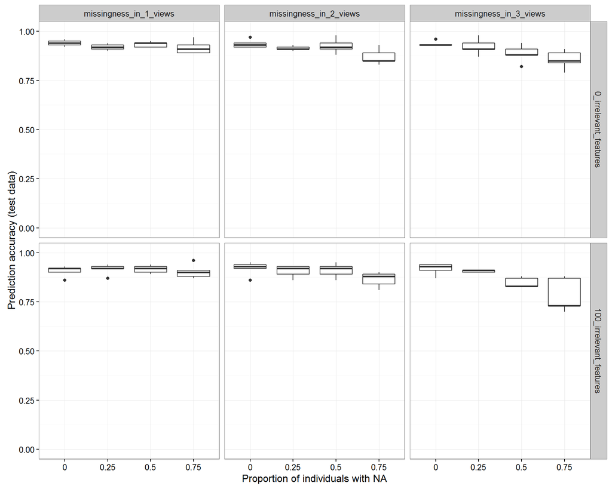

### Regression

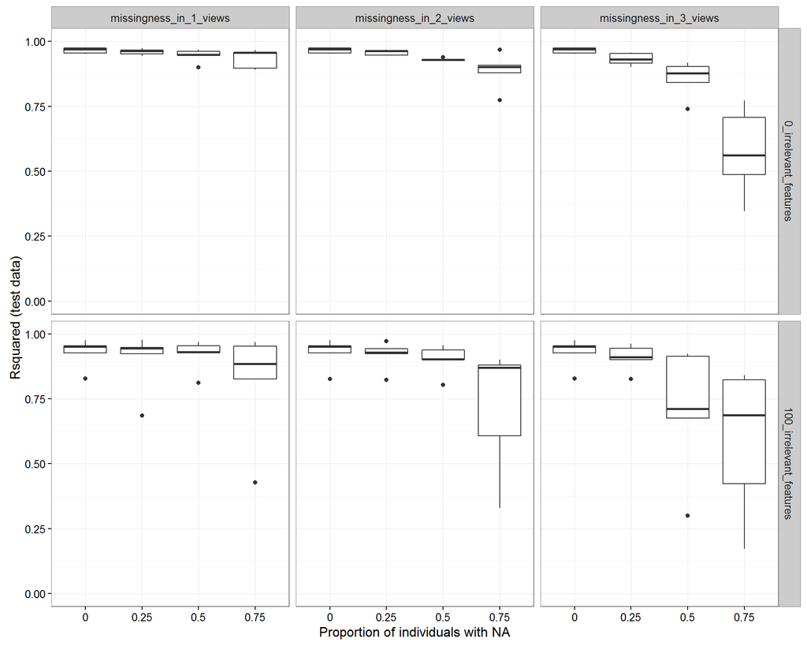

Conclusion: Even 50% of missingness in 3 out of 4 views is still sufficient for reasonable accuracy.

### Two-dimensional latent space

Lets try to get some insight, by exploring perhaps the simplest example, two dimensional latent space.

Suppose $(v_1, v_2) \sim N(0, I)$ for all data points. Then we construct two views, each with 10 features by

- $w^r_1 v_1$ for feature $r$ of the first view
- $\tilde{w}^r_1 v_1 + \tilde{w}^r_2 v_2$ for feature $r$ of the second view

so that the two views “share” some information, but are not redundant.

We define two classes according to logistic regression in the latent space. Lets plot the data (color denotes class)

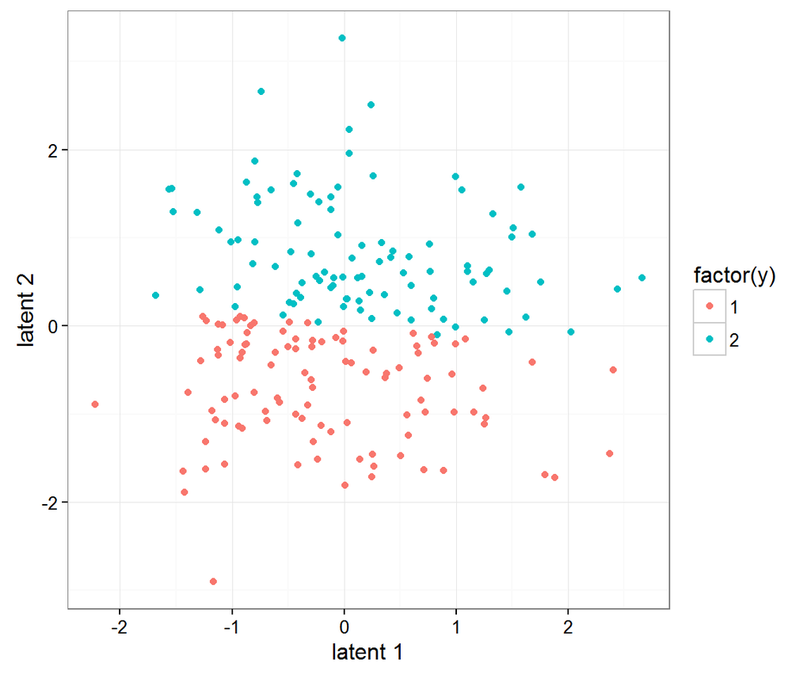

Now, suppose $50\%$ of the individuals have the first view missing.

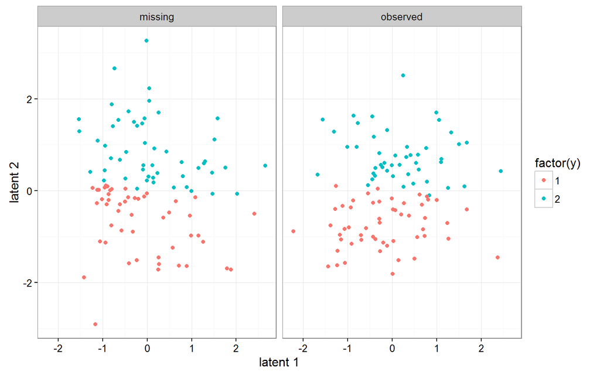

We divide them into equally sized train and test sets, run the multi-view method, and impute their values. Lets see the results, separately for

- test and train
- individuals with one view missing, vs those observed

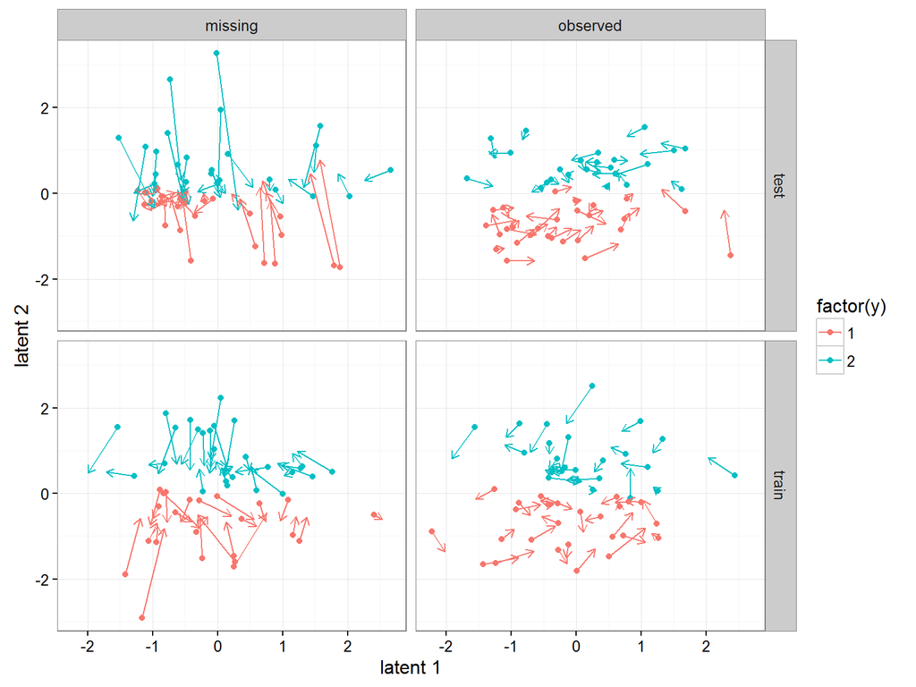

Observations:

- for observed data (both train and test), the inferred latent representation pretty much agrees with the ground truth
- for missing test data, the deviation from the truth is quite large.